# (Ford GoBike System Data)¶

Bashayer Alshehri (1 Aug, 2020)

- Introduction
- Preliminary Wrangling
- Gathering Data
- Assessing and Cleaning Data
- Univariate Exploration
- Bivariate Exploration
- Multivariate Exploration

## Introduction:

Bay Wheels is a regional public bicycle sharing system in California's San Francisco Bay Area. It is operated by Motivate in a partnership with the Metropolitan Transportation Commission and the Bay Area Air Quality Management District.Bay Wheels is the first regional and large-scale bicycle sharing system deployed in California and on the West Coast of the United States. It was established as Bay Area Bike Share in August 2013. As of January 2018, the Bay Wheels system had over 2,600 bicycles in 262 stations across San Francisco, East Bay and San Jose.

In June 2017 the system was officially re-launched as Ford GoBike in a partnership with Ford Motor Company. After Motivate's acquisition by Lyft, the system was renamed to Bay Wheels in June 2019.The system is expected to expand to 7,000 bicycles around 540 stations in San Francisco, Oakland, Berkeley, Emeryville, and San Jose.

In this project I aim to practice Data Visualization which's an important step in Data Analysis, The Dataset that I used is the Ford GoBike System Data for 2018

you can find the dataset here : https://www.lyft.com/bikes/bay-wheels/system-data

## 1- Preliminary Wrangling:

```python
# import all packages and set plots to be embedded inline
import numpy as np
import pandas as pd
import matplotlib.pyplot as plt
import seaborn as sb
import datetime as dt

%matplotlib inline
```

### 1-1 Gathering Data:

```python
# loading datasets for the year 2018
df_Jan = pd.read_csv('201801-fordgobike-tripdata.csv')
df_Feb = pd.read_csv('201802-fordgobike-tripdata.csv')
df_Mar = pd.read_csv('201803-fordgobike-tripdata.csv')
df_Apr = pd.read_csv('201804-fordgobike-tripdata.csv')
df_May = pd.read_csv('201805-fordgobike-tripdata.csv')
df_Jun = pd.read_csv('201806-fordgobike-tripdata.csv')
df_Jul = pd.read_csv('201807-fordgobike-tripdata.csv')
df_Aug = pd.read_csv('201808-fordgobike-tripdata.csv')
df_Sep = pd.read_csv('201809-fordgobike-tripdata.csv')
df_Oct = pd.read_csv('201810-fordgobike-tripdata.csv')
df_Nov = pd.read_csv('201811-fordgobike-tripdata.csv')
df_Dec = pd.read_csv('201812-fordgobike-tripdata.csv')
```

> The Dataset is from "Ford GoBike System Data" for all months in 2018.

### 1-2 Assessing and Cleaning Data:

```python
#check if all csv files have the same structure.
print(df_Jan.dtypes)
print()
print(df_Feb.dtypes)
print()
print(df_Mar.dtypes)
print()
print(df_Apr.dtypes)
print()
print(df_May.dtypes)
print()
print(df_Jun.dtypes)
print()
print(df_Jul.dtypes)
print()
print(df_Aug.dtypes)
print()
print(df_Sep.dtypes)
print()
print(df_Oct.dtypes)
print()
print(df_Nov.dtypes)
print()
print(df_Dec.dtypes)
```

```
duration_sec                 int64
start_time                  object
end_time                    object
start_station_id             int64
start_station_name          object
start_station_latitude     float64
start_station_longitude    float64
end_station_id               int64
end_station_name            object
end_station_latitude       float64
end_station_longitude      float64
bike_id                      int64
user_type                   object
bike_share_for_all_trip     object
dtype: object

duration_sec                 int64
start_time                  object
end_time                    object
start_station_id             int64
start_station_name          object
start_station_latitude     float64
start_station_longitude    float64
end_station_id               int64
end_station_name            object
end_station_latitude       float64
end_station_longitude      float64
bike_id                      int64
user_type                   object
bike_share_for_all_trip     object
dtype: object

duration_sec                 int64
start_time                  object
end_time                    object
start_station_id             int64
start_station_name          object
start_station_latitude     float64
start_station_longitude    float64
end_station_id               int64
```

[output cut: 136 more lines]

```
duration_sec                 int64
start_time                  object
end_time                    object
start_station_id           float64
start_station_name          object
start_station_latitude     float64
start_station_longitude    float64
end_station_id             float64
end_station_name            object
end_station_latitude       float64
end_station_longitude      float64
bike_id                      int64
user_type                   object
bike_share_for_all_trip     object
dtype: object
```

```python
#add month coloumn to contact all dataset
df_Jan['Month']='Jan';
df_Feb['Month']='Feb';
df_Mar['Month']='Mar';
df_Apr['Month']='Apr';
df_May['Month']='May';
df_Jun['Month']='Jun';
df_Jul['Month']='Jul';
df_Aug['Month']='Aug';
df_Sep['Month']='Sep';
df_Oct['Month']='Oct';
df_Nov['Month']='Nov';
df_Dec['Month']='Dec';
```

```python
# Merge all the datasets together
df = pd.concat([df_Jan,df_Feb,df_Mar,df_Apr,df_May,df_Jun,df_Jul,df_Aug,df_Sep,df_Oct,df_Nov,df_Dec])
```

```python
#check
df
```

|  | duration_sec | start_time | end_time | start_station_id | start_station_name | start_station_latitude | start_station_longitude | end_station_id | end_station_name | end_station_latitude | end_station_longitude | bike_id | user_type | bike_share_for_all_trip | Month |
| --- | --- | --- | --- | --- | --- | --- | --- | --- | --- | --- | --- | --- | --- | --- | --- |
| 0 | 75284 | 2018-01-31 22:52:35.2390 | 2018-02-01 19:47:19.8240 | 120.0 | Mission Dolores Park | 37.761420 | -122.426435 | 285.0 | Webster St at O'Farrell St | 37.783521 | -122.431158 | 2765 | Subscriber | No | Jan |
| 1 | 85422 | 2018-01-31 16:13:34.3510 | 2018-02-01 15:57:17.3100 | 15.0 | San Francisco Ferry Building (Harry Bridges Pl... | 37.795392 | -122.394203 | 15.0 | San Francisco Ferry Building (Harry Bridges Pl... | 37.795392 | -122.394203 | 2815 | Customer | No | Jan |
| 2 | 71576 | 2018-01-31 14:23:55.8890 | 2018-02-01 10:16:52.1160 | 304.0 | Jackson St at 5th St | 37.348759 | -121.894798 | 296.0 | 5th St at Virginia St | 37.325998 | -121.877120 | 3039 | Customer | No | Jan |
| 3 | 61076 | 2018-01-31 14:53:23.5620 | 2018-02-01 07:51:20.5000 | 75.0 | Market St at Franklin St | 37.773793 | -122.421239 | 47.0 | 4th St at Harrison St | 37.780955 | -122.399749 | 321 | Customer | No | Jan |
| 4 | 39966 | 2018-01-31 19:52:24.6670 | 2018-02-01 06:58:31.0530 | 74.0 | Laguna St at Hayes St | 37.776435 | -122.426244 | 19.0 | Post St at Kearny St | 37.788975 | -122.403452 | 617 | Subscriber | No | Jan |
| ... | ... | ... | ... | ... | ... | ... | ... | ... | ... | ... | ... | ... | ... | ... | ... |
| 131358 | 473 | 2018-12-01 00:11:54.8110 | 2018-12-01 00:19:48.5470 | 345.0 | Hubbell St at 16th St | 37.766474 | -122.398295 | 81.0 | Berry St at 4th St | 37.775880 | -122.393170 | 3035 | Subscriber | No | Dec |
| 131359 | 841 | 2018-12-01 00:02:48.7260 | 2018-12-01 00:16:49.7660 | 10.0 | Washington St at Kearny St | 37.795393 | -122.404770 | 58.0 | Market St at 10th St | 37.776619 | -122.417385 | 2034 | Subscriber | No | Dec |
| 131360 | 260 | 2018-12-01 00:05:27.6150 | 2018-12-01 00:09:47.9560 | 245.0 | Downtown Berkeley BART | 37.870139 | -122.268422 | 255.0 | Virginia St at Shattuck Ave | 37.876573 | -122.269528 | 2243 | Subscriber | No | Dec |
| 131361 | 292 | 2018-12-01 00:03:06.5490 | 2018-12-01 00:07:59.0800 | 93.0 | 4th St at Mission Bay Blvd S | 37.770407 | -122.391198 | 126.0 | Esprit Park | 37.761634 | -122.390648 | 545 | Subscriber | No | Dec |
| 131362 | 150 | 2018-12-01 00:03:05.7420 | 2018-12-01 00:05:36.0260 | 107.0 | 17th St at Dolores St | 37.763015 | -122.426497 | 119.0 | 18th St at Noe St | 37.761047 | -122.432642 | 4319 | Subscriber | No | Dec |

1863721 rows × 15 columns

```python
# Check
df['Month'].value_counts()
```

```
Oct    201458
Jul    199222
Jun    195968
Aug    192162
Sep    186217
May    179125
Nov    134135
Dec    131363
Apr    131169
Mar    111382
Feb    106718
Jan     94802
Name: Month, dtype: int64
```

```python
df.shape
```

```
(1863721, 15)
```

> 1863721 records and 15 features.

```python
df.info()
```

```
<class 'pandas.core.frame.DataFrame'>
Int64Index: 1863721 entries, 0 to 131362
Data columns (total 15 columns):
 #   Column                   Dtype
---  ------                   -----
 0   duration_sec             int64
 1   start_time               object
 2   end_time                 object
 3   start_station_id         float64
 4   start_station_name       object
 5   start_station_latitude   float64
 6   start_station_longitude  float64
 7   end_station_id           float64
 8   end_station_name         object
 9   end_station_latitude     float64
 10  end_station_longitude    float64
 11  bike_id                  int64
 12  user_type                object
 13  bike_share_for_all_trip  object
 14  Month                    object
dtypes: float64(6), int64(2), object(7)
memory usage: 227.5+ MB
```

```python
print(df.dtypes)
```

```
duration_sec                 int64
start_time                  object
end_time                    object
start_station_id           float64
start_station_name          object
start_station_latitude     float64
start_station_longitude    float64
end_station_id             float64
end_station_name            object
end_station_latitude       float64
end_station_longitude      float64
bike_id                      int64
user_type                   object
bike_share_for_all_trip     object
Month                       object
dtype: object
```

```python
print(df.describe())
```

```
       duration_sec  start_station_id  start_station_latitude  \
count  1.863721e+06      1.851950e+06            1.863721e+06
mean   8.573026e+02      1.196744e+02            3.776678e+01
std    2.370379e+03      1.003976e+02            1.057689e-01
min    6.100000e+01      3.000000e+00            3.726331e+01
25%    3.500000e+02      3.300000e+01            3.777106e+01
50%    5.560000e+02      8.900000e+01            3.778107e+01
75%    8.720000e+02      1.860000e+02            3.779625e+01
max    8.636600e+04      3.810000e+02            4.551000e+01

       start_station_longitude  end_station_id  end_station_latitude  \
count             1.863721e+06    1.851950e+06          1.863721e+06
mean             -1.223492e+02    1.181730e+02          3.776690e+01
std               1.654634e-01    1.004403e+02          1.056483e-01
min              -1.224737e+02    3.000000e+00          3.726331e+01
25%              -1.224114e+02    3.000000e+01          3.777106e+01
50%              -1.223974e+02    8.800000e+01          3.778127e+01
75%              -1.222865e+02    1.830000e+02          3.779728e+01
max              -7.357000e+01    3.810000e+02          4.551000e+01

       end_station_longitude       bike_id
count           1.863721e+06  1.863721e+06
mean           -1.223487e+02  2.296851e+03
std             1.650597e-01  1.287733e+03
min            -1.224737e+02  1.100000e+01
25%            -1.224094e+02  1.225000e+03
50%            -1.223971e+02  2.338000e+03
75%            -1.222894e+02  3.333000e+03
max            -7.357000e+01  6.234000e+03
```

> Ford has actually given us a pretty clean dataset to work with.

### What is the structure of your dataset?

- This data include about '1863721' records and 15 features.
- The feature are :
  - duration_sec -----> int64
  - start_time -----> object
  - end_time -----> object
  - start_station_id -----> float64
  - start_station_name -----> object
  - start_station_latitude -----> float64
  - start_station_longitude -----> float64
  - end_station_id -----> float64
  - end_station_name -----> object
  - end_station_latitude -----> float64
  - end_station_longitude -----> float64
  - bike_id -----> int64
  - user_type -----> object
  - bike_share_for_all_trip -----> object
  - Month -----> object
- Most variables numeric (int,float),but the variables 'start_time','end_time','start_station_name','end_station_name' ,'user_type','bike_share_for_all_trip','Month' are string.

### What is/are the main feature(s) of interest in your dataset?

1- What is the distribution of trip duration?!

2- What is the Start Time of trips by Month?!

3- What is the distribution of the user type variable?!

4- The relationship between average bike ride time and months of the year.

5- The relationship between seasons and the trip duration in hours.

6- The relationship between all numeric variables.

7- The longest trip duration per month for both subscriber and customer.

8- Rush time per month for weekdays.

### What features in the dataset do you think will help support your investigation into your feature(s) of interest?

trip duration and the user type to see who has more influence than the other.

## Univariate Exploration

> In this section, investigate distributions of individual variables.

### 1- What is the distribution of trip duration?!

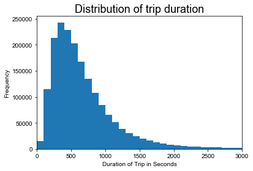

```python
#Visualizing the data in a histogram
dur_bins = np.arange(0, df['duration_sec'].max() + 100, 100)
plt.hist(data = df, x = 'duration_sec', bins = dur_bins);

plt.xlim(0, 3000);
plt.style.use('seaborn')
plt.title('Distribution of trip duration', fontsize = 18);
plt.xlabel('Duration of Trip in Seconds');
plt.ylabel('Frequency');
plt.style.use('seaborn');
```

### 2- What is the Start Time of trips by Month?!

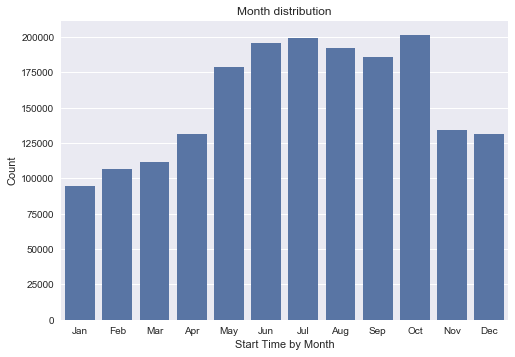

```python
base_color = sb.color_palette()[0]
sb.countplot(data=df, x='Month', color=base_color)
plt.xlabel('Start Time by Month')
plt.ylabel('Count')
plt.title('Month distribution');
```

> It seems that October is the most month that people use bikes, the lowest month is January.

### 3- What is the distribution of the user type variable?!

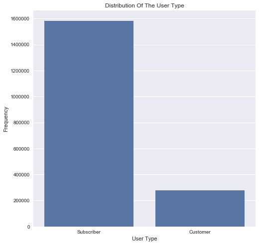

```python
plt.figure(figsize = [8, 8])
base_color = sb.color_palette()[0]
sb.countplot(data = df, x = 'user_type', color = base_color);
plt.title("Distribution Of The User Type")
plt.xlabel("User Type")
plt.ylabel("Frequency")
plt.show();
```

> It seems that the Subscriber is the most frequent.

### Of the features you investigated, were there any unusual distributions? Did you perform any operations on the data to tidy, adjust, or change the form of the data? If so, why did you do this?

- No need to perform any operation to clean the data, it was clean and tidy.

## Bivariate Exploration

> In this section, investigate relationships between pairs of variables in the data.

```python
df.info()
```

[output not shown]

### 1- The relationship between average bike ride time and months of the year.

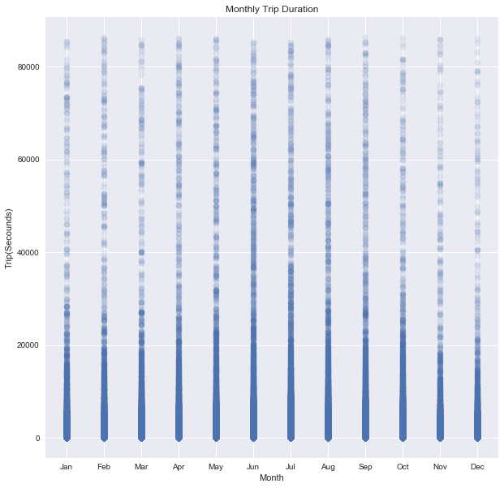

```python
# Now check the bike ride duration for each month
plt.figure(figsize = [10,10])
plt.scatter(data = df , x = 'Month' , y = 'duration_sec' , alpha = 0.1 )
plt.title('Monthly Trip Duration')
plt.xlabel('Month')
plt.ylabel('Trip(Secounds)');
```

- There was a constant limit throughout the year and it was about 15,000 seconds.
- June and July had the longest trips during those months.
- November and December had fewer trips that lasted as long.

### 2- The relationship between seasons and the trip duration in hours.

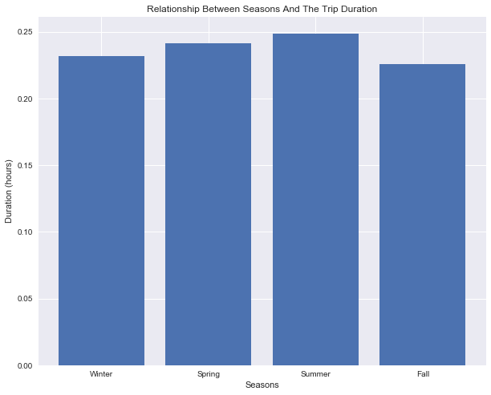

```python
df['duration_hours'] = df['duration_sec'] / 3600

winter = df.query('Month in ["Dec" , "Jan" , "Feb"]' ).duration_hours.mean()
spring = df.query('Month in ["Mar" , "Apr" , "May"]' ).duration_hours.mean ()
summer = df.query('Month in ["Jun" , "Jul" , "Aug"] ').duration_hours.mean()
fall = df.query('Month in ["Sep" , "Nov" , "Dec"] ').duration_hours.mean()

plt.figure(figsize=[10,8])
plt.bar(['Winter','Spring','Summer','Fall'],[winter , spring , summer , fall] )
plt.title("Relationship Between Seasons And The Trip Duration")
plt.xlabel("Seasons")
plt.ylabel("Duration (hours)");
```

### 3- The relationship between all numeric variables.

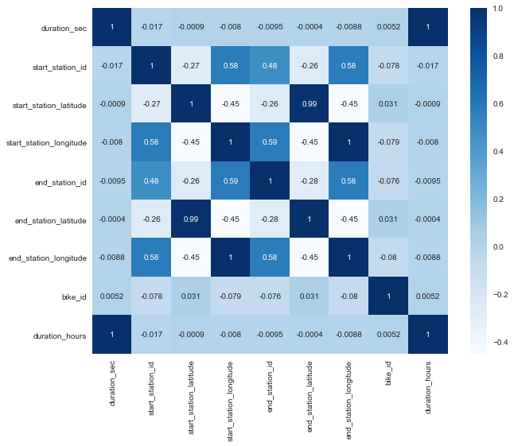

```python
plt.figure(figsize = [10, 8])
sb.heatmap(df.corr(), annot = True,cmap = 'Blues')
plt.show()
```

> The heatmap plot shows that there are lots of negative correlation and few strong correlation.

### Did you observe any interesting relationships between the other features (not the main feature(s) of interest)?

> In the seasons plot even though the seasons were close to each other but there is slightly different that Summer season has the longest trip duration

## Multivariate Exploration

> Create plots of three or more variables .

### 1- The longest trip duration per month for both subscriber and customer?

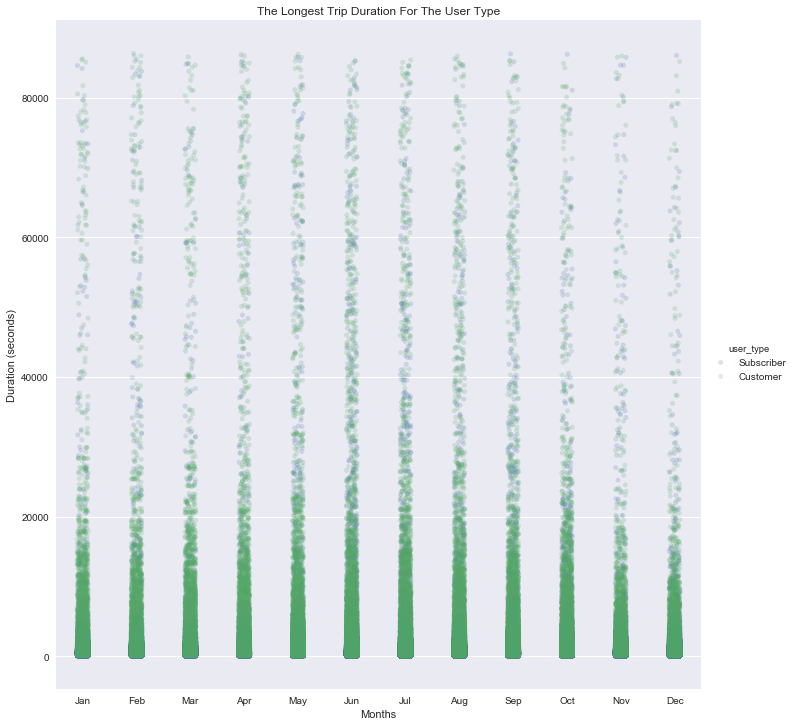

```python
lo = sb.FacetGrid(data =  df, hue = 'user_type', height = 10)
lo.map(sb.stripplot, 'Month','duration_sec', alpha = 1/5 )
lo.add_legend();
plt.title("The Longest Trip Duration For The User Type")
plt.xlabel("Months")
plt.ylabel("Duration (seconds)");
```

> As we can see that customer through all of the months has longer trips duration than subscriber

### 2- Rush time per month for weekdays?

```python
weekday={0:'Mon', 1:'Tue', 2:'Wed', 3:'Thu', 4:'Fri', 5:'Sat', 6:'Sun'}

df['start_time'] = pd.to_datetime(df['start_time'])
df['weekday'] = df['start_time'].dt.dayofweek.map(weekday)

df['weekday'].value_counts()
```

```
Tue    319332
Wed    316374
Thu    314124
Mon    294573
Fri    290390
Sat    175614
Sun    153314
Name: weekday, dtype: int64
```

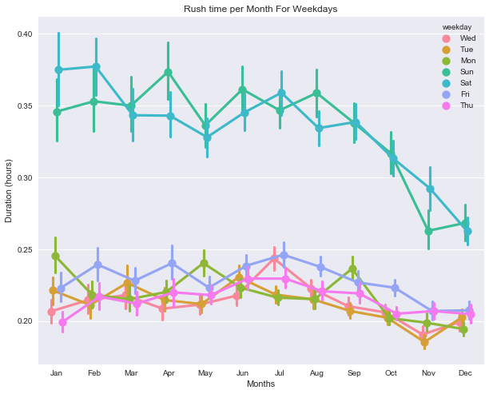

```python
plt.figure(figsize=[10,8])
sb.pointplot(data=df,x='Month',y='duration_hours',hue='weekday', dodge = 0.3 )
plt.title("Rush time per Month For Weekdays")
plt.xlabel("Months")
plt.ylabel("Duration (hours)");
```

### Talk about some of the relationships you observed in this part of the investigation. Were there features that strengthened each other in terms of looking at your feature(s) of interest?

> In the first plot the customer has longer trips duration than subscriber through all of the months

### Were there any interesting or surprising interactions between features?

> In the second plot with the weekdays varible it has an impact on the result for the months because I found that the rush time at begging of the year months and in two days unlike before with user type was in the October